# Week 9

Group 3: Mara Alexeev, Parker Bannister, Mitchell Flagg

November 9, 2020

To dos -clean up deliverables -change everything to week 9 names. -combine terms and redo text analysis

**Deliverables:**

Code available at our github repo: MaraAlexeev/720_regex_mmp

Error analysis of the top 10 false positive and false negative terms

Model Output - same as prior week: group3_predictions_wk9.csv

# Libraries

```r
#get relevant libraries
library(tidyverse)
library(forcats)
#install.packages("caret")
#library(caret)
#install.packages("rlang")
#install.packages("cvms")
#install.packages("cvms")
library(cvms)
#install.packages("tidyr")
library(tidyr)
#library(broom)
library(tibble)
#install.packages("here")
library(here)
#library(tidytext)
#install.packages("ggimage")
library(ggimage)
#install.packages("rsvg")
library(rsvg)
#library(textstem)
library(text2vec)
library(data.table)

#install.packages("glmnet")
#library(glmnet)
library(ROCR)
library(pROC)
```

# Functions

```r
search_assign_by_cc <- function(data, search_terms, column_to_search) {
  pasted_match <- paste(search_terms, collapse = "|")

  searched_and_assigned <- data %>%
  mutate(covid_guess = as.integer(grepl(pattern = pasted_match, x = column_to_search, ignore.case = TRUE)))

  return(searched_and_assigned)
}

covid_prediction_count <- function(data) {
  prediction_count <- data %>%
  group_by(covid_guess) %>%
  summarise(count = n())

  return(prediction_count)
}

covid_model_comparison <- function(data_predictions, data_w_labels) {
  only_labeled_rows <- data_w_labels %>%
    filter(label == "0"| label == "1")

  joined_data <- only_labeled_rows %>%
  left_join(data_predictions, by = "id")

  joined_data$label <- as.numeric(joined_data$label)

  renamed_joined_data <- joined_data %>%
  rename(
    covid_status = label,
    covid_prediction = covid_guess
    )

  error_analysis <- renamed_joined_data %>%
 mutate(results =  case_when(
    covid_status == 0 & covid_prediction == 0 ~ "True Negative",
    covid_status == 1 & covid_prediction == 1 ~ "True Positive",
    covid_status == 0 & covid_prediction == 1 ~ "False Positive",
    covid_status == 1 & covid_prediction == 0 ~ "False Negative"
  )
 )
  return(error_analysis)
}

covid_model_comparison_table <- function(data_with_status_and_prediction){
  real_and_prediction <- data_with_status_and_prediction %>%
  group_by(covid_status, covid_prediction) %>%
  summarise(count = n())

   return(real_and_prediction)
}

evaluation_table <- function(covid_model){

model_basic_table <- data.frame("target" = c(covid_model$covid_status),
                                  "prediction"= c(covid_model$covid_prediction))

model_eval <- evaluate(model_basic_table,
                 target_col = "target",
                 prediction_col = "prediction",
                 type = "binomial")

return(model_eval)
}

#Function to sort results by cc

cc_by_results <- function(model, results_factor, cc_number_to_return = 10) {
  results_filtered <- model %>%
  filter(results == results_factor)

  top_cc <- results_filtered%>%
  group_by(results, grouped_cc) %>%
  summarise(count = n()) %>%
  arrange(desc(count)) %>%
  head(cc_number_to_return)


  return(print(top_cc))
}
```

## Load data files

```r
#read in data
# covidclass_without_labels <- read.table("./data_do_not_alter/covidclass_without_labels.csv",
#                                         na.strings = "", header = TRUE, sep = "\t")
#
# covidclass_w_labels <- read.table("./data_do_not_alter/covidclass_30_percent_labels.csv",
#                                         na.strings = "", header = TRUE, sep = "\t")

covidclass_70percentlabels <- read.table("data_do_not_alter/covidclass_70percentlabels.csv",  na.strings = "", header = TRUE, sep = "|", quote = "", comment.char = "", col.names = c("id", "chief_complaint_1", "chief_complaint_2", "thirty_label", "seventy_label"))
```

## Clean Data

```r
#Cleaning rows 4010 and 6713 with extra quotation marks
covidclass_70percentlabels[4010,1] <- 4010
covidclass_70percentlabels[4010,5] <- 0
covidclass_70percentlabels[6713,1] <- 6713
covidclass_70percentlabels[6713,5] <- 0

#Making empty chief complaint clearer
covidclass_70percentlabels$chief_complaint_1[which(is.na(covidclass_70percentlabels$chief_complaint_1))] <-  "No CC provided"


covidclass_70percentlabels$id <- as.numeric(covidclass_70percentlabels$id)
```

```r
#Combine concepts that are similar but different encodings of the same chief complaint to account for different spellings and misspellings or abbreviations

sob_concept <- c("SOB",     "SOB - SHORTNESS OF BREATH", "SHORT OF BREATH", "SHORT OF BREATHE", "SHORTNESS OF BREATH")
fever_concept <- c("FEVER", "FEVERS")
ili_concept <- c("\\bILI\\b", "FLU", "FLU-LIKE SYMPTOMS", "ILI - INFLUENZE LIKE ILLNESS",   "INFLUENZA LIKE ILLNESS", "INFLUENZA", "I L I", "ILI")
cough_concept <- c("COUGH", "COUGH/CONGESTION", "Productive cough", "PRODUCTIVE COUGH")
hypoxia_concept <- c("HYPOXEMIA", "HYPOXIA", "HYPOXIC")
dyspnea_concept <- c("DYPNEA", "DYSPNEA")
doe_concept <- c("DOE - DYSPNEA ON EXERTION", "DYSPNEA ON EXERTION")
resp_dis_concept <- c("RESP DISTRESS",  "RESPIRATORY DISTRESS")

combined_cc_data <- covidclass_70percentlabels %>%
  mutate(grouped_cc = case_when(
    chief_complaint_1 %in% sob_concept ~ "shortness of breath",
    chief_complaint_1 %in% fever_concept ~ "fever",
    chief_complaint_1 %in% ili_concept ~ "ili",
    chief_complaint_1 %in% cough_concept ~ "cough",
    chief_complaint_1 %in% hypoxia_concept ~ "hypoxia",
    chief_complaint_1 %in% dyspnea_concept ~ "dyspnea",
    chief_complaint_1 %in% doe_concept ~ "doe",
    chief_complaint_1 %in% resp_dis_concept ~ "respiratory distress",
    TRUE                           ~ .$chief_complaint_1
    )
  )

week_9_labeled_data <- combined_cc_data %>%
  filter(!is.na(seventy_label)) %>%
  mutate(covid_label = case_when(
    seventy_label == "0" ~ 0,
    seventy_label == "1" ~ 1
  ))


week_9_predictions <- combined_cc_data %>%
    mutate(covid_label = case_when(
    seventy_label == "0" ~ 0,
    seventy_label == "1" ~ 1
  ))
```

## Random Forest

```r
library(randomForest)
library(caTools)
library(tm)
library(SnowballC)
```

```r
#https://www.pluralsight.com/guides/machine-learning-text-data-using-r

corpus <-  Corpus(VectorSource(week_9_labeled_data$grouped_cc))
corpus[[1]][1]
```

```
## $content
## [1] "shortness of breath"
```

```r
corpus <-  tm_map(corpus, PlainTextDocument)
corpus  <-  tm_map(corpus, tolower)
corpus <- tm_map(corpus, removePunctuation)
corpus[[1]][1]
```

```
## $content
## [1] "shortness of breath"
```

```r
corpus <-  tm_map(corpus, removeWords, c(stopwords("english")))
corpus[[1]][1]
```

```
## $content
## [1] "shortness  breath"
```

```r
corpus <-  tm_map(corpus, stemDocument)
corpus[[1]][1]
```

```
## $content
## [1] "short breath"
```

```r
frequencies  <-  DocumentTermMatrix(corpus)

sparse <-  removeSparseTerms(frequencies, 0.995)

tSparse <-  as.data.frame(as.matrix(sparse))
colnames(tSparse) <-  make.names(colnames(tSparse))

columns_to_keep <- colnames(tSparse)

tSparse$covid_label <-  week_9_labeled_data$covid_label
```

```r
prop.table(table(tSparse$covid_label))
```

```
##
##          0          1
## 0.93867564 0.06132436
```

```r
set.seed(888)
split  <-  sample.split(tSparse$covid_label, SplitRatio = 0.7)
trainSparse  <-  subset(tSparse, split==TRUE)
testSparse <-  subset(tSparse, split==FALSE)
```

```r
# k <- 0.99999
# RF_model  <-  randomForest(covid_label ~ ., data=trainSparse, importance = TRUE, cutoff = c(k, 1-k))
# varImpPlot(RF_model)
#
# predictRF <-  predict(RF_model, newdata=testSparse)
# table(testSparse$covid_label, predictRF)
#
```

## Trying something new

Searching online found that the randomForest() does not work well with sparse data or data with just one variable. Here we try `xgboost`.

```r
require(xgboost)
require(Matrix)
require(data.table)
```

```r
#sparse_matrix <- sparse.model.matrix(covid_label ~ ., data = trainSparse)[,-1]

#Drop the covid_label from being in the training
data_matrix <- as.matrix(trainSparse[,colnames(trainSparse) != "covid_label"])
output_vector  <-  as.matrix(trainSparse[,"covid_label"])

bst <- xgboost(data = data_matrix, label = output_vector, scale_pos_weight = 20, nrounds = 20,objective = "binary:logistic")
data_matrix_test <- as.matrix(testSparse[,colnames(testSparse) != "covid_label"])

pred <- predict(bst, data_matrix_test)

prediction <- as.numeric(pred > 0.5)
```

```r
test_data <- data.frame(testSparse)
test_data <- rownames_to_column(test_data, var = "id")
prediction <- data.frame(prediction)

data_and_prediction <-cbind(test_data, prediction)

small_d_and_p <- data_and_prediction %>%
  select("id", "prediction", "covid_label")
table(small_d_and_p$prediction, small_d_and_p$covid_label)
```

```
##
##        0    1
##   0 1379   60
##   1  462   60
```

```r
corpus_f <-  Corpus(VectorSource(week_9_predictions$grouped_cc))

corpus_f <-  tm_map(corpus_f, PlainTextDocument)
corpus_f  <-  tm_map(corpus_f, tolower)
corpus_f <- tm_map(corpus_f, removePunctuation)
corpus_f <-  tm_map(corpus_f, removeWords, c(stopwords("english")))
corpus_f <-  tm_map(corpus_f, stemDocument)
frequencies_f  <-  DocumentTermMatrix(corpus_f)

frequencies_f_all_columns <-  as.data.frame(as.matrix(frequencies_f))

full_data_top_columns <- frequencies_f_all_columns %>%
  select(columns_to_keep)
```

```
## Note: Using an external vector in selections is ambiguous.
## i Use `all_of(columns_to_keep)` instead of `columns_to_keep` to silence this message.
## i See <https://tidyselect.r-lib.org/reference/faq-external-vector.html>.
```

```r
full_data_top_columns$covid_label <-  (week_9_predictions$covid_label)

data_matrix_full <- as.matrix(full_data_top_columns[,colnames(full_data_top_columns) != "covid_label"])

pred_full <- predict(bst, data_matrix_full)
pred_full <- data.frame(pred_full)
```

## Predicted probabilities and cutoff

```r
week_9_predictions$predictions <- pred_full$pred_full

cut_off_w9 <- 0.5
week_9_predictions <- week_9_predictions %>%
  mutate(final_prediction_w9 = case_when(
    predictions >= cut_off_w9 ~ 1,
    predictions < cut_off_w9 ~ 0,
  ))

week_9_predictions_errors <- week_9_predictions %>%
  filter(!is.na(covid_label))

table(week_9_predictions_errors$covid_label, week_9_predictions_errors$final_prediction_w9)
```

```
##
##        0    1
##   0 4635 1503
##   1  162  239
```

## ROC curves

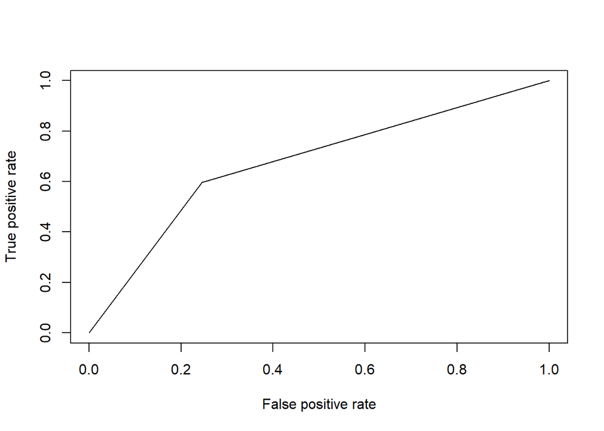

```r
pred_week_9 <- prediction(week_9_predictions_errors$final_prediction_w9, week_9_predictions_errors$covid_label)
perf_week_9 <- performance(pred_week_9,"tpr","fpr")
plot(perf_week_9,colorize=FALSE)
```

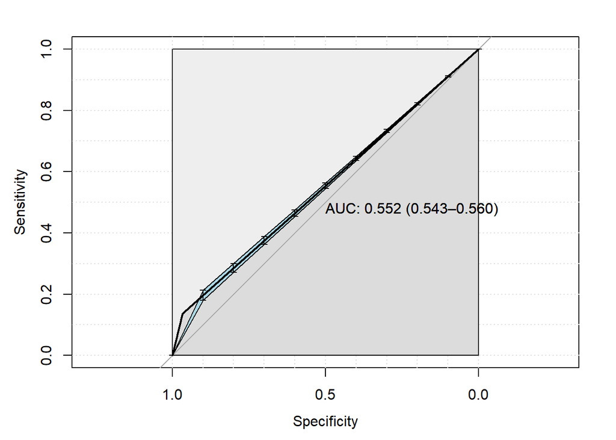

```r
pROC_obj <- roc(week_9_predictions_errors$final_prediction_w9, week_9_predictions_errors$covid_label,
            smoothed = TRUE,
            # arguments for ci
            ci=TRUE, ci.alpha=0.9, stratified=FALSE,
            # arguments for plot
            plot=TRUE, auc.polygon=TRUE, max.auc.polygon=TRUE, grid=TRUE,
            print.auc=TRUE, show.thres=TRUE)
sens.ci <- ci.se(pROC_obj)
plot(sens.ci, type="shape", col="lightblue")
## Warning in plot.ci.se(sens.ci, type = "shape", col = "lightblue"): Low
## definition shape.
plot(sens.ci, type="bars")
```

```r
model_w9 <- data.frame("target" = c(week_9_predictions_errors$covid_label),
                                  "prediction"= c(week_9_predictions_errors$final_prediction_w9))

model_eval_w9 <- evaluate(model_w9,
                 target_col = "target",
                 prediction_col = "prediction",
                 type = "binomial")

model_eval_w9
```

```
## # A tibble: 1 x 19
##   `Balanced Accur~ Accuracy    F1 Sensitivity Specificity `Pos Pred Value`
##              <dbl>    <dbl> <dbl>       <dbl>       <dbl>            <dbl>
## 1            0.676    0.745 0.223       0.596       0.755            0.137
## # ... with 13 more variables: `Neg Pred Value` <dbl>, AUC <dbl>, `Lower
## #   CI` <dbl>, `Upper CI` <dbl>, Kappa <dbl>, MCC <dbl>, `Detection
## #   Rate` <dbl>, `Detection Prevalence` <dbl>, Prevalence <dbl>,
## #   Predictions <list>, ROC <named list>, `Confusion Matrix` <list>,
## #   Process <list>
```

# Comparison to week 8

Week 8 results on test: sensitivity 0.285714286 specificity 0.864125122 PPV 0.122105263 NPV 0.948158742 accuracy 0.828239609 f1 0.171091445

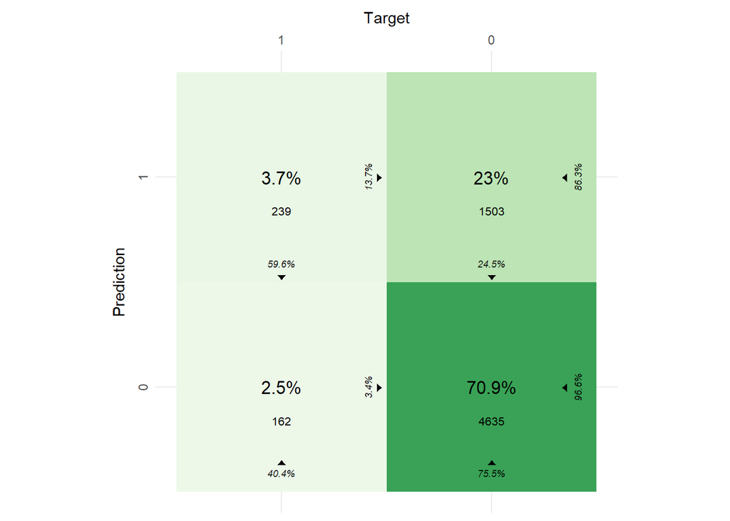

```r
plot_confusion_matrix(model_eval_w9, palette = "Greens")
```

# Error Analysis

```r
error_analysis <- week_9_predictions_errors %>%
 mutate(results =  case_when(
    covid_label == 0 & final_prediction_w9 == 0 ~ "True Negative",
    covid_label == 1 & final_prediction_w9 == 1 ~ "True Positive",
    covid_label == 0 & final_prediction_w9 == 1 ~ "False Positive",
    covid_label == 1 & final_prediction_w9 == 0 ~ "False Negative"
  ))
```

```r
tp_model_1 <- cc_by_results(error_analysis, "True Positive")
```

```
## # A tibble: 10 x 3
## # Groups:   results [1]
##    results       grouped_cc                  count
##    <chr>         <chr>                       <int>
##  1 True Positive cough                          70
##  2 True Positive fever                          42
##  3 True Positive shortness of breath            36
##  4 True Positive ili                            22
##  5 True Positive hypoxia                        12
##  6 True Positive dyspnea                        10
##  7 True Positive ALTERED MENTAL STATUS           8
##  8 True Positive BODY ACHES                      8
##  9 True Positive DIARRHEA                        7
## 10 True Positive AMS - ALTERED MENTAL STATUS     5
```

```r
tn_model_1 <- cc_by_results(error_analysis, "True Negative")
```

```
## # A tibble: 10 x 3
## # Groups:   results [1]
##    results       grouped_cc      count
##    <chr>         <chr>           <int>
##  1 True Negative ABD PAIN          215
##  2 True Negative ABDOMINAL PAIN    189
##  3 True Negative STOMACH ACHE      179
##  4 True Negative ABNORMAL LABS     168
##  5 True Negative S/P FALL          140
##  6 True Negative CHEST PRESSURE    101
##  7 True Negative CP - CHEST PAIN    97
##  8 True Negative CHEST PAIN         92
##  9 True Negative BACK PAIN          91
## 10 True Negative DIZZINESS          91
```

```r
fp_model_1 <- cc_by_results(error_analysis, "False Positive")
```

```
## # A tibble: 10 x 3
## # Groups:   results [1]
##    results        grouped_cc                  count
##    <chr>          <chr>                       <int>
##  1 False Positive shortness of breath           369
##  2 False Positive fever                         258
##  3 False Positive cough                         145
##  4 False Positive dyspnea                       137
##  5 False Positive AMS - ALTERED MENTAL STATUS    88
##  6 False Positive ALTERED MENTAL STATUS          85
##  7 False Positive ili                            60
##  8 False Positive DIARRHEA                       55
##  9 False Positive doe                            43
## 10 False Positive BODY ACHES                     32
```

```r
fn_model_1 <- cc_by_results(error_analysis, "False Negative")
```

```
## # A tibble: 10 x 3
## # Groups:   results [1]
##    results        grouped_cc           count
##    <chr>          <chr>                <int>
##  1 False Negative WEAKNESS                 7
##  2 False Negative ABNORMAL LABS            6
##  3 False Negative BACK PAIN                6
##  4 False Negative S/P FALL                 6
##  5 False Negative STOMACH ACHE             6
##  6 False Negative CHEST PRESSURE           5
##  7 False Negative CP - CHEST PAIN          5
##  8 False Negative respiratory distress     5
##  9 False Negative ABD PAIN                 4
## 10 False Negative ABDOMINAL PAIN           4
```

```r
all_results_model_1 <- bind_rows(tp_model_1, tn_model_1, fp_model_1, fn_model_1)

all_results_model_1_wide <- pivot_wider(all_results_model_1, names_from = results, values_from = count, values_fill = 0)
```

## Thoughts

Overall it seems like a non-linear classifier is more of a black box when it comes to understanding the predicted scores for the different chief complaints. The linear model was easier and faster to build and run. However, because it could oversimplfy the relationship of inputs and responses, it might miss out on more complicated relationships one can find with non-linear models. Non-linear models are however prone to overfitting training data and can then perform much worse than expected on new data inputs.

## Model Output

```r
#Our COVID prediction is labeled in the column "final_prediction_w9"
group3_predictions_wk9 <- week_9_predictions
write_csv(group3_predictions_wk9, "./analysis/group3_predictions_wk9.csv")
```